# Treball aliments

JV

29/12/2022

# Preàmbul

*Abans de res, revisar que els titols i els noms dels eixos siguin els correctes!*

L’objectiu d’aquestes pràctiques és determinar les diferències entre les propietats de certs eliments -per exemple, el % d’humitat.

S’apliquen els seguents test:

- Shapiro–Wilk: “En estadística, la prueba de Shapiro–Wilk se usa para contrastar la normalidad de un conjunto de datos. Se plantea como hipótesis nula que una muestra proviene de una población normalmente distribuida. Fue publicado en 1965 por Samuel Shapiro y Martin Wilk. Se considera uno de las pruebas más potentes para el contraste de normalidad.”
- Si suposam normalitat:
  - [Anova](https://es.wikipedia.org/wiki/An%C3%A1lisis_de_la_varianza): Serveix per estudiar la variança
  - [T-Student](https://es.wikipedia.org/wiki/Prueba_t_de_Student) + Bonferroni:“es cualquier prueba en la que el estadístico utilizado tiene una distribución t de Student si la hipótesis nula es cierta. Se aplica cuando la población estudiada sigue una distribución normal, pero el tamaño muestral es demasiado pequeño como para que el estadístico en el que está basada la inferencia esté normalmente distribuido, utilizándose una estimación de la desviación típica en lugar del valor real” + “La prueba de hipótesis estadística se basa en rechazar la hipótesis nula si la probabilidad de los datos observados en las hipótesis nulas es baja. Si se prueban múltiples hipótesis, aumenta la probabilidad de un evento raro y, por lo tanto, aumenta la probabilidad de rechazar incorrectamente una hipótesis nula (es decir, cometer un error de tipo I.)”
- Si NO suposam normalitat:
  - Kruskal-Wallis: Com l’ANOVA però no assumeix normalitat
  - Wilcoxon: “La prueba de los rangos con signo de Wilcoxon es una prueba no paramétrica para comparar el rango medio de dos muestras relacionadas y determinar si existen diferencias entre ellas. Se utiliza como alternativa a la prueba t de Student cuando no se puede suponer la normalidad de dichas muestras.”

# Pràctica 1:

## Gràfica

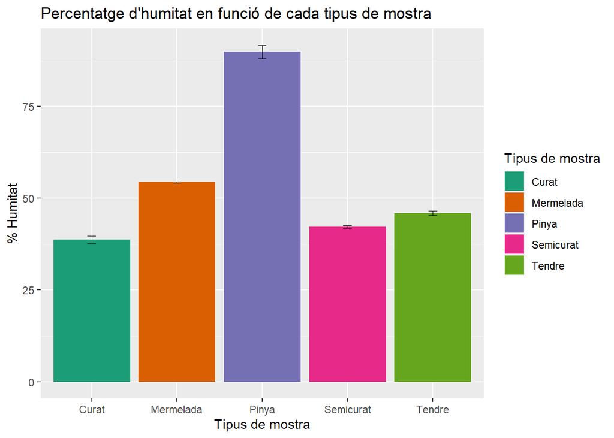

## Test

```r
data <- practica_1
colnames(data) <- c("Mostra", "Contingut", "Mitjana", "Error")

# Comporvam normalitat
shapiro.test(data$Contingut)
```

```
##
##  Shapiro-Wilk normality test
##
## data:  data$Contingut
## W = 0.71897, p-value = 0.0001338
```

```r
# Si es normal: Anova
summary(aov(data$Contingut ~ data$Mostra))
```

```
##             Df Sum Sq Mean Sq F value   Pr(>F)
## data$Mostra  4   5563    1391   470.8 6.41e-14 ***
## Residuals   13     38       3
## ---
## Signif. codes:  0 '***' 0.001 '**' 0.01 '*' 0.05 '.' 0.1 ' ' 1
```

```r
# Si es normal: t.test
pairwise.t.test(data$Contingut, data$Mostra, paired = FALSE,  p.adjust.method = "bonferroni")
```

```
##
##  Pairwise comparisons using t tests with pooled SD
##
## data:  data$Contingut and data$Mostra
##
##           Curat   Mermelada Pinya   Semicurat
## Mermelada 2.3e-07 -         -       -
## Pinya     7.4e-14 1.9e-11   -       -
## Semicurat 0.12685 4.6e-06   1.9e-13 -
## Tendre    0.00048 0.00024   5.3e-13 0.09081
##
## P value adjustment method: bonferroni
```

```r
# Si no es normal: Kruskal test
kruskal.test(data$Contingut ~ data$Mostra)
```

```
##
##  Kruskal-Wallis rank sum test
##
## data:  data$Contingut by data$Mostra
## Kruskal-Wallis chi-squared = 16.07, df = 4, p-value = 0.002926
```

```r
# Si no es normal: Wilcoxon test
pairwise.wilcox.test(data$Contingut, data$Mostra, paired = FALSE, p.adjust.method = "holm")
```

```
##
##  Pairwise comparisons using Wilcoxon rank sum exact test
##
## data:  data$Contingut and data$Mostra
##
##           Curat Mermelada Pinya Semicurat
## Mermelada 0.46  -         -     -
## Pinya     0.46  0.46      -     -
## Semicurat 0.46  0.46      0.46  -
## Tendre    0.29  0.46      0.46  0.29
##
## P value adjustment method: holm
```

# Pràctica 2

## Pràctica 2.1.

### Gràfic

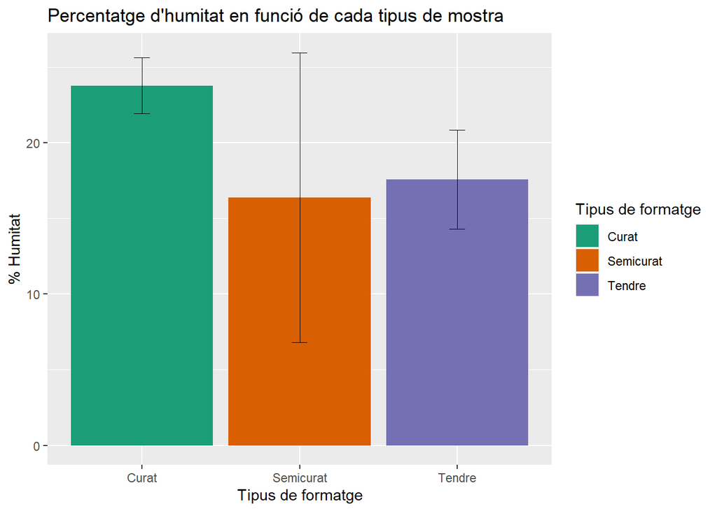

### Test

```r
data <- practica_21
colnames(data) <- c("Mostra", "Contingut", "Mitjana", "Error")

# Comporvam normalitat
shapiro.test(data$Contingut)
```

```
##
##  Shapiro-Wilk normality test
##
## data:  data$Contingut
## W = 0.88514, p-value = 0.2935
```

```r
# Si es normal: Anova
summary(aov(data$Contingut ~ data$Mostra))
```

```
##             Df Sum Sq Mean Sq F value Pr(>F)
## data$Mostra  2   62.9   31.45   0.446  0.677
## Residuals    3  211.3   70.45
```

```r
# Si es normal: t.test
pairwise.t.test(data$Contingut, data$Mostra, paired = FALSE,  p.adjust.method = "bonferroni")
```

```
##
##  Pairwise comparisons using t tests with pooled SD
##
## data:  data$Contingut and data$Mostra
##
##           Curat Semicurat
## Semicurat 1     -
## Tendre    1     1
##
## P value adjustment method: bonferroni
```

```r
# Si no es normal: Kruskal test
kruskal.test(data$Contingut ~ data$Mostra)
```

```
##
##  Kruskal-Wallis rank sum test
##
## data:  data$Contingut by data$Mostra
## Kruskal-Wallis chi-squared = 1.1429, df = 2, p-value = 0.5647
```

```r
# Si no es normal: Wilcoxon test
pairwise.wilcox.test(data$Contingut, data$Mostra, paired = FALSE, p.adjust.method = "holm")
```

```
##
##  Pairwise comparisons using Wilcoxon rank sum exact test
##
## data:  data$Contingut and data$Mostra
##
##           Curat Semicurat
## Semicurat 1     -
## Tendre    1     1
##
## P value adjustment method: holm
```

## Pràctica 2.2

### Gràfic

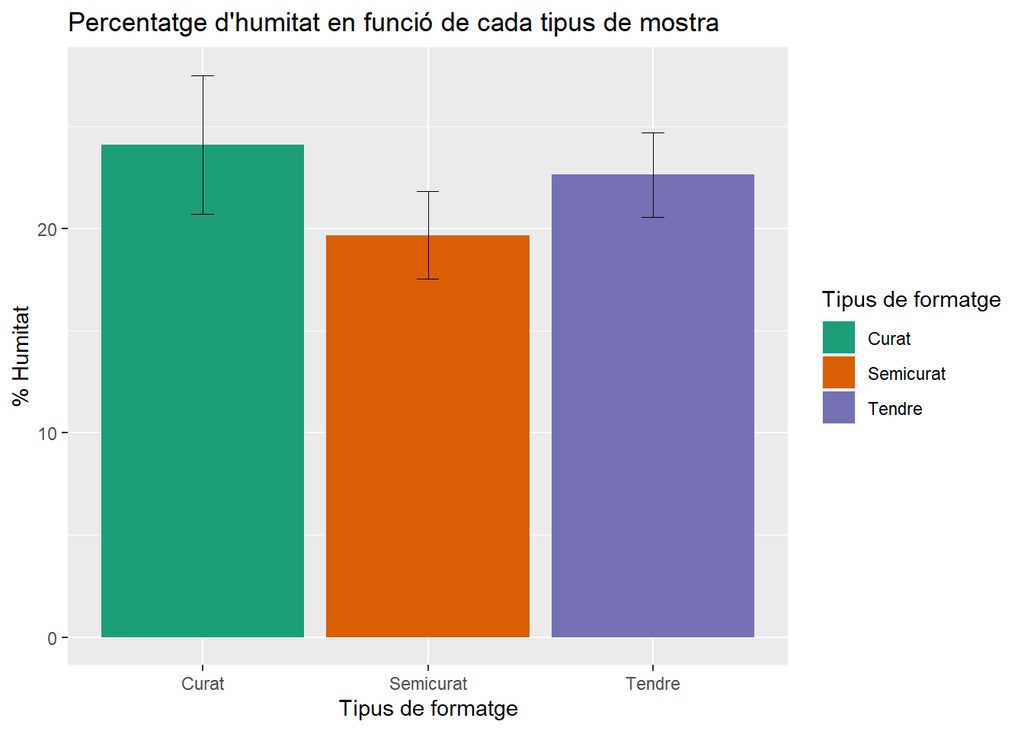

### Test

```r
data <- practica_22
colnames(data) <- c("Mostra", "Contingut", "Mitjana", "Error")

# Comporvam normalitat
shapiro.test(data$Contingut)
```

```
##
##  Shapiro-Wilk normality test
##
## data:  data$Contingut
## W = 0.93706, p-value = 0.5513
```

```r
# Si es normal: Anova
summary(aov(data$Contingut ~ data$Mostra))
```

```
##             Df Sum Sq Mean Sq F value Pr(>F)
## data$Mostra  2  26.07   13.04   0.672  0.545
## Residuals    6 116.38   19.40
```

```r
# Si es normal: t.test
pairwise.t.test(data$Contingut, data$Mostra, paired = FALSE,  p.adjust.method = "bonferroni")
```

```
##
##  Pairwise comparisons using t tests with pooled SD
##
## data:  data$Contingut and data$Mostra
##
##           Curat Semicurat
## Semicurat 0.87  -
## Tendre    1.00  1.00
##
## P value adjustment method: bonferroni
```

```r
# Si no es normal: Kruskal test
kruskal.test(data$Contingut ~ data$Mostra)
```

```
##
##  Kruskal-Wallis rank sum test
##
## data:  data$Contingut by data$Mostra
## Kruskal-Wallis chi-squared = 1.6, df = 2, p-value = 0.4493
```

```r
# Si no es normal: Wilcoxon test
pairwise.wilcox.test(data$Contingut, data$Mostra, paired = FALSE, p.adjust.method = "holm")
```

```
##
##  Pairwise comparisons using Wilcoxon rank sum exact test
##
## data:  data$Contingut and data$Mostra
##
##           Curat Semicurat
## Semicurat 1     -
## Tendre    1     1
##
## P value adjustment method: holm
```

# Pràctica 3

## Pràctica 3.1

### Gràfic

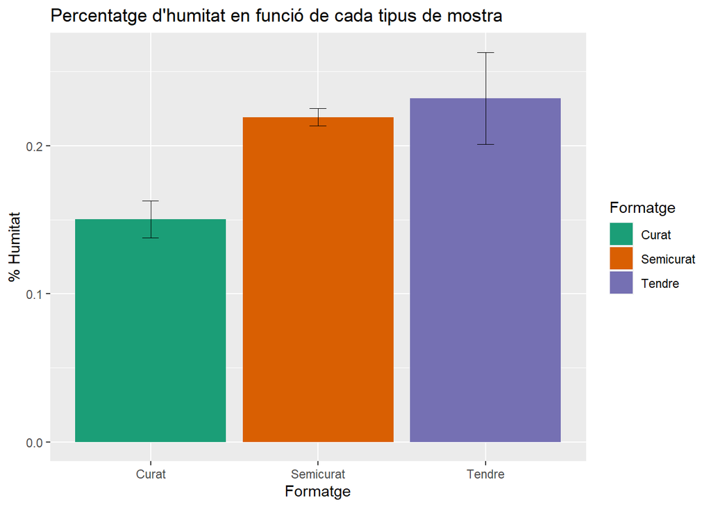

### Test

```r
data <- practica_31
colnames(data) <- c("Mostra", "Contingut", "Mitjana", "Error")

# Comporvam normalitat
shapiro.test(data$Contingut)
```

```
##
##  Shapiro-Wilk normality test
##
## data:  data$Contingut
## W = 0.96201, p-value = 0.8191
```

```r
# Si es normal: Anova
summary(aov(data$Contingut ~ data$Mostra))
```

```
##             Df   Sum Sq  Mean Sq F value Pr(>F)
## data$Mostra  2 0.011615 0.005808   4.996 0.0528 .
## Residuals    6 0.006974 0.001162
## ---
## Signif. codes:  0 '***' 0.001 '**' 0.01 '*' 0.05 '.' 0.1 ' ' 1
```

```r
# Si es normal: t.test
pairwise.t.test(data$Contingut, data$Mostra, paired = FALSE,  p.adjust.method = "bonferroni")
```

```
##
##  Pairwise comparisons using t tests with pooled SD
##
## data:  data$Contingut and data$Mostra
##
##           Curat Semicurat
## Semicurat 0.144 -
## Tendre    0.078 1.000
##
## P value adjustment method: bonferroni
```

```r
# Si no es normal: Kruskal test
kruskal.test(data$Contingut ~ data$Mostra)
```

```
##
##  Kruskal-Wallis rank sum test
##
## data:  data$Contingut by data$Mostra
## Kruskal-Wallis chi-squared = 5.4222, df = 2, p-value = 0.06646
```

```r
# Si no es normal: Wilcoxon test
pairwise.wilcox.test(data$Contingut, data$Mostra, paired = FALSE, p.adjust.method = "holm")
```

```
##
##  Pairwise comparisons using Wilcoxon rank sum exact test
##
## data:  data$Contingut and data$Mostra
##
##           Curat Semicurat
## Semicurat 0.3   -
## Tendre    0.3   1.0
##
## P value adjustment method: holm
```

## Pràctica 3.2

### Gràfic

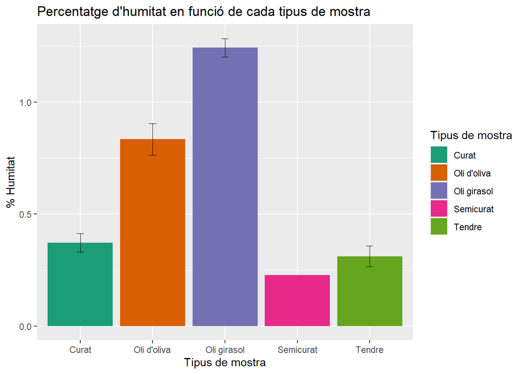

### Test

```r
data <- practica_32
colnames(data) <- c("Mostra", "Contingut", "Mitjana", "Error")

# Comporvam normalitat
shapiro.test(data$Contingut)
```

```
##
##  Shapiro-Wilk normality test
##
## data:  data$Contingut
## W = 0.85684, p-value = 0.02754
```

```r
# Si es normal: Anova
summary(aov(data$Contingut ~ data$Mostra))
```

```
##             Df Sum Sq Mean Sq F value   Pr(>F)
## data$Mostra  4 1.9823  0.4956   65.94 1.15e-06 ***
## Residuals    9 0.0676  0.0075
## ---
## Signif. codes:  0 '***' 0.001 '**' 0.01 '*' 0.05 '.' 0.1 ' ' 1
## 1 observation deleted due to missingness
```

```r
# Si es normal: t.test
pairwise.t.test(data$Contingut, data$Mostra, paired = FALSE,  p.adjust.method = "bonferroni")
```

```
##
##  Pairwise comparisons using t tests with pooled SD
##
## data:  data$Contingut and data$Mostra
##
##             Curat Oli d'oliva Oli girasol Semicurat
## Oli d'oliva -     -           -           -
## Oli girasol -     -           -           -
## Semicurat   -     -           -           -
## Tendre      -     -           -           -
##
## P value adjustment method: bonferroni
```

```r
# Si no es normal: Kruskal test
kruskal.test(data$Contingut ~ data$Mostra)
```

```
##
##  Kruskal-Wallis rank sum test
##
## data:  data$Contingut by data$Mostra
## Kruskal-Wallis chi-squared = 11, df = 4, p-value = 0.02656
```

```r
# Si no es normal: Wilcoxon test
pairwise.wilcox.test(data$Contingut, data$Mostra, paired = FALSE, p.adjust.method = "holm")
```

```
##
##  Pairwise comparisons using Wilcoxon rank sum exact test
##
## data:  data$Contingut and data$Mostra
##
##             Curat Oli d'oliva Oli girasol Semicurat
## Oli d'oliva 0.57  -           -           -
## Oli girasol 0.57  0.80        -           -
## Semicurat   1.00  1.00        1.00        -
## Tendre      1.00  0.80        0.80        1.00
##
## P value adjustment method: holm
```

## Pràctica 3.3

### Gràfic

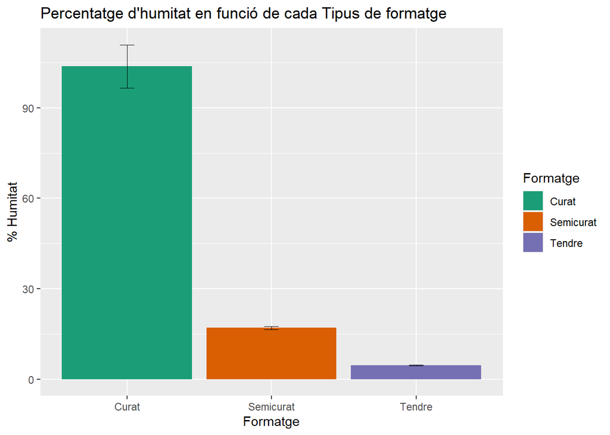

### Test

```r
data <- practica_33
colnames(data) <- c("Mostra", "Contingut", "Mitjana", "Error")

# Comporvam normalitat
shapiro.test(data$Contingut)
```

```
##
##  Shapiro-Wilk normality test
##
## data:  data$Contingut
## W = 0.79521, p-value = 0.03672
```

```r
# Si es normal: Anova
summary(aov(data$Contingut ~ data$Mostra))
```

```
##             Df Sum Sq Mean Sq F value   Pr(>F)
## data$Mostra  2  14980    7490   97.38 0.000405 ***
## Residuals    4    308      77
## ---
## Signif. codes:  0 '***' 0.001 '**' 0.01 '*' 0.05 '.' 0.1 ' ' 1
## 2 observations deleted due to missingness
```

```r
# Si es normal: t.test
pairwise.t.test(data$Contingut, data$Mostra, paired = FALSE,  p.adjust.method = "bonferroni")
```

```
##
##  Pairwise comparisons using t tests with pooled SD
##
## data:  data$Contingut and data$Mostra
##
##           Curat   Semicurat
## Semicurat 0.00124 -
## Tendre    0.00073 0.68285
##
## P value adjustment method: bonferroni
```

```r
# Si no es normal: Kruskal test
kruskal.test(data$Contingut ~ data$Mostra)
```

```
##
##  Kruskal-Wallis rank sum test
##
## data:  data$Contingut by data$Mostra
## Kruskal-Wallis chi-squared = 5.3571, df = 2, p-value = 0.06866
```

```r
# Si no es normal: Wilcoxon test
pairwise.wilcox.test(data$Contingut, data$Mostra, paired = FALSE, p.adjust.method = "holm")
```

```
##
##  Pairwise comparisons using Wilcoxon rank sum exact test
##
## data:  data$Contingut and data$Mostra
##
##           Curat Semicurat
## Semicurat 0.6   -
## Tendre    0.6   0.6
##
## P value adjustment method: holm
```

# Pràctica 4

## Gràfic

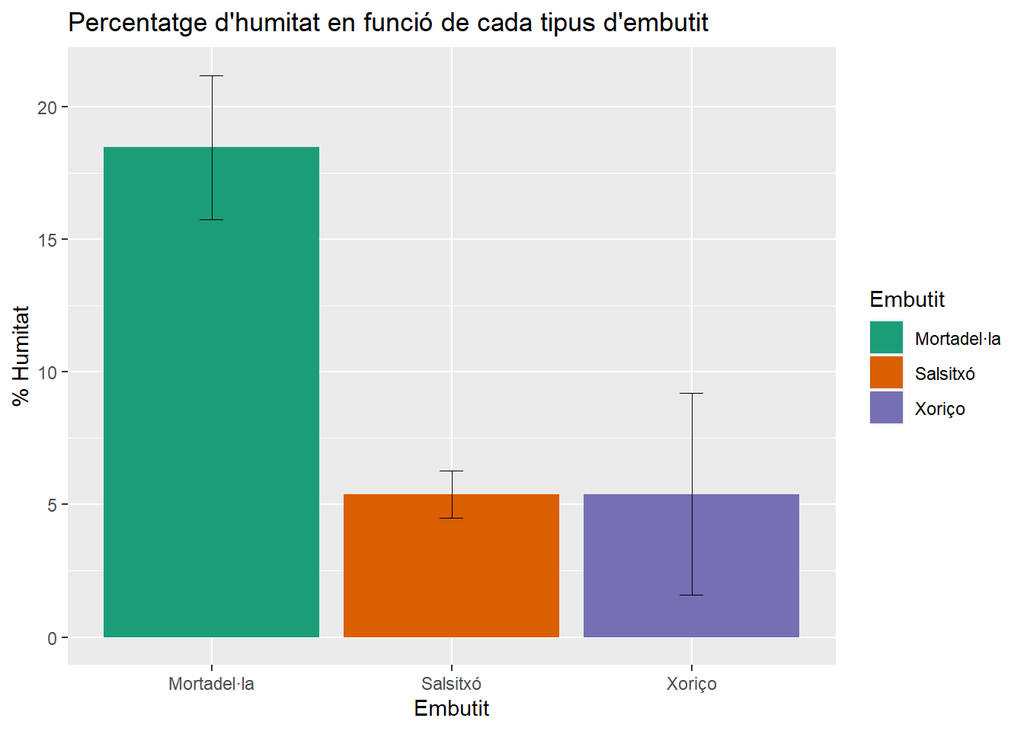

## Test

```r
data <- practica_4
colnames(data) <- c("Mostra", "Contingut", "Mitjana", "Error")

# Comporvam normalitat
shapiro.test(data$Contingut)
```

```
##
##  Shapiro-Wilk normality test
##
## data:  data$Contingut
## W = 0.92383, p-value = 0.4997
```

```r
# Si es normal: Anova
summary(aov(data$Contingut ~ data$Mostra))
```

```
##             Df Sum Sq Mean Sq F value Pr(>F)
## data$Mostra  2 293.68  146.84   7.875  0.041 *
## Residuals    4  74.59   18.65
## ---
## Signif. codes:  0 '***' 0.001 '**' 0.01 '*' 0.05 '.' 0.1 ' ' 1
## 2 observations deleted due to missingness
```

```r
# Si es normal: t.test
pairwise.t.test(data$Contingut, data$Mostra, paired = FALSE,  p.adjust.method = "bonferroni")
```

```
##
##  Pairwise comparisons using t tests with pooled SD
##
## data:  data$Contingut and data$Mostra
##
##          Mortadel·la Salsitxó
## Salsitxó 0.088       -
## Xoriço   0.088       1.000
##
## P value adjustment method: bonferroni
```

```r
# Si no es normal: Kruskal test
kruskal.test(data$Contingut ~ data$Mostra)
```

```
##
##  Kruskal-Wallis rank sum test
##
## data:  data$Contingut by data$Mostra
## Kruskal-Wallis chi-squared = 4.5, df = 2, p-value = 0.1054
```

```r
# Si no es normal: Wilcoxon test
pairwise.wilcox.test(data$Contingut, data$Mostra, paired = FALSE, p.adjust.method = "holm")
```

```
##
##  Pairwise comparisons using Wilcoxon rank sum exact test
##
## data:  data$Contingut and data$Mostra
##
##          Mortadel·la Salsitxó
## Salsitxó 0.6         -
## Xoriço   0.6         1.0
##
## P value adjustment method: holm
```